```python
from IPython.display import HTML
from IPython.display import display
tag = HTML('''<script>
code_show=true;
function code_toggle() {
    if (code_show){
        $('div.cell.code_cell.rendered.selected div.input').hide();
    } else {
        $('div.cell.code_cell.rendered.selected div.input').show();
    }
    code_show = !code_show
}
$( document ).ready(code_toggle);
</script>
<style>
.border { border-width: 2px; border-color: black; border-style: solid; }
</style>
''')
display(tag)
```

```python
#Programming in Python II progject assignment
# Student Name : Joseph Hencil Peter
# Student NRIC : S7967093F
```

# Programming in Python II - Project

For this project, you have to provide the solutions for the following 3 questions. Code your answers directly into the cell after each question. Be sure to run them to ensure that your code works. After you have filled up the answers, proceed back to where you downloaded this file to submit your solutions!

All the best!

## Question 1 - Advanced Python

### Given the following statements containing a list with 3 tuples (each tuple describes a book title, pages, and price):

```python
lst = [('Beginning iOS Programming', 534, 34.99),
       ('Beginning Android Programming', 484, 29.99),
       ('Python Machine Learning', 284, 39.99)]
```

### Using a lambda function, write the statement to sort the list of tuples based on:

### a. Book Title (alphabetical order)

```python
#---type your answer here---
#sort based on the first item (book title) in the tuple
sorted(lst, key=lambda x: x[0])
```

```
[('Beginning Android Programming', 484, 29.99),
 ('Beginning iOS Programming', 534, 34.99),
 ('Python Machine Learning', 284, 39.99)]
```

### b. Number of Pages (ascending order)

```python
#---type your answer here---
#sort based on the second item (number of pages) in the tuple
sorted(lst, key=lambda x: x[1])
```

```
[('Python Machine Learning', 284, 39.99),
 ('Beginning Android Programming', 484, 29.99),
 ('Beginning iOS Programming', 534, 34.99)]
```

### c. Price (descending order; i.e. most expensive to the cheapest)

```python
#---type your answer here---

#sort (descending) based on the third item (price) in the tuple
sorted(lst, key=lambda x: x[2], reverse=True)
```

```
[('Python Machine Learning', 284, 39.99),
 ('Beginning iOS Programming', 534, 34.99),
 ('Beginning Android Programming', 484, 29.99)]
```

## Question 2 - NumPy

Given the following code:

```python
import numpy as np
a1 = np.round(20 * np.random.random((4,5)), 2)
```

### a. Print out the `a1` array.

```python
#---type your answer here---

#print the elements of array a1
print(a1)
```

```
[[13.26  8.71 11.09 17.22 14.26]
 [13.2  14.18  9.98  9.62  2.9 ]
 [ 4.76 11.99  0.79 16.79  2.54]
 [ 5.    3.56 12.33  1.71 12.14]]
```

### b. Find and list out the mean of each row in the array

```python
#---type your answer here---

#mean of each row
print(a1.mean(axis=1))
```

```
[12.908  9.976  7.374  6.948]
```

### c. In the `a1` array, find the number that is closest to the smallest mean.

*Hint: You will need to use a combination of numpy functions such as flat, abs, and argmin)*

```python
#---type your answer here---

#find row wise mean
row_mean= a1.mean(axis=1)

#find the close mean indexes ( abs of diff between each item and row mean)
closeMeanIndexes = np.transpose(abs(a1.T - row_mean).argmin(axis=0))

smallMeanResult = []
rowIndex = -1
#extract the close mean value and append it in result list
for columnIndex in closeMeanIndexes:
    rowIndex = rowIndex + 1
    smallMeanResult.append(a1[rowIndex, columnIndex])

#print the final result (each row's closest item/value  to the mean)
print(smallMeanResult)
```

```
[13.26, 9.98, 4.76, 5.0]
```

## Question 3 - Pandas

For this question, you are given the following dataset - **Automobile_data.csv**.

```python
import pandas as pd

df = pd.read_csv("Automobile_data.csv")
```

### a. Print the first 5 rows and the last 7 rows of the dataset, like this:

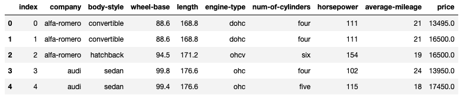

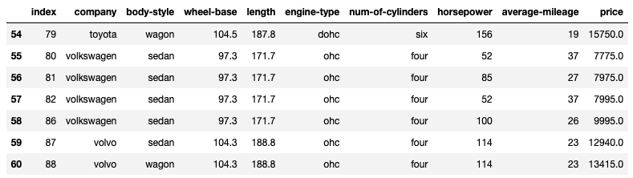

```python
#---type your answer here---

#print the first 5 records
df.head(5)
```

|  | index | company | body-style | wheel-base | length | engine-type | num-of-cylinders | horsepower | average-mileage | price |
| --- | --- | --- | --- | --- | --- | --- | --- | --- | --- | --- |
| 0 | 0 | alfa-romero | convertible | 88.6 | 168.8 | dohc | four | 111 | 21 | 13495.0 |
| 1 | 1 | alfa-romero | convertible | 88.6 | 168.8 | dohc | four | 111 | 21 | 16500.0 |
| 2 | 2 | alfa-romero | hatchback | 94.5 | 171.2 | ohcv | six | 154 | 19 | 16500.0 |
| 3 | 3 | audi | sedan | 99.8 | 176.6 | ohc | four | 102 | 24 | 13950.0 |
| 4 | 4 | audi | sedan | 99.4 | 176.6 | ohc | five | 115 | 18 | 17450.0 |

```python
#---type your answer here---

#print the last 7 records
df.tail(7)
```

|  | index | company | body-style | wheel-base | length | engine-type | num-of-cylinders | horsepower | average-mileage | price |
| --- | --- | --- | --- | --- | --- | --- | --- | --- | --- | --- |
| 54 | 79 | toyota | wagon | 104.5 | 187.8 | dohc | six | 156 | 19 | 15750.0 |
| 55 | 80 | volkswagen | sedan | 97.3 | 171.7 | ohc | four | 52 | 37 | 7775.0 |
| 56 | 81 | volkswagen | sedan | 97.3 | 171.7 | ohc | four | 85 | 27 | 7975.0 |
| 57 | 82 | volkswagen | sedan | 97.3 | 171.7 | ohc | four | 52 | 37 | 7995.0 |
| 58 | 86 | volkswagen | sedan | 97.3 | 171.7 | ohc | four | 100 | 26 | 9995.0 |
| 59 | 87 | volvo | sedan | 104.3 | 188.8 | ohc | four | 114 | 23 | 12940.0 |
| 60 | 88 | volvo | wagon | 104.3 | 188.8 | ohc | four | 114 | 23 | 13415.0 |

### b. Find the company with the most expensive car:

```python
#---type your answer here---

#find the company with most expensive car.
#first filter the row with max price. then print the value
df[df['price'] == max(df['price'])] [['company','price']]
```

|  | company | price |
| --- | --- | --- |
| 35 | mercedes-benz | 45400.0 |

### c. Write the statements to print out each company’s most expensive car:

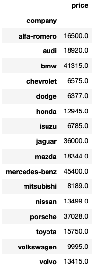

```python
#---type your answer here---

# apply group by 'company', then filter the max price row in each group and print
df.groupby(by='company').max('price')[ ['price']]
```

| company | price |
| --- | --- |
| alfa-romero | 16500.0 |
| audi | 18920.0 |
| bmw | 41315.0 |
| chevrolet | 6575.0 |
| dodge | 6377.0 |
| honda | 12945.0 |
| isuzu | 6785.0 |
| jaguar | 36000.0 |
| mazda | 18344.0 |
| mercedes-benz | 45400.0 |
| mitsubishi | 8189.0 |
| nissan | 13499.0 |
| porsche | 37028.0 |
| toyota | 15750.0 |
| volkswagen | 9995.0 |
| volvo | 13415.0 |

### d. Write the statements to print out the average mileage of each car maker:

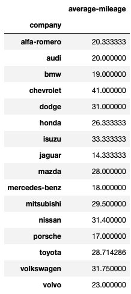

```python
#---type your answer here---

#apply group by 'company', find the mean of 'average-mileage' in each group and print
df.groupby(by='company').mean('average-mileage')[ ['average-mileage']]
```

| company | average-mileage |
| --- | --- |
| alfa-romero | 20.333333 |
| audi | 20.000000 |
| bmw | 19.000000 |
| chevrolet | 41.000000 |
| dodge | 31.000000 |
| honda | 26.333333 |
| isuzu | 33.333333 |
| jaguar | 14.333333 |
| mazda | 28.000000 |
| mercedes-benz | 18.000000 |
| mitsubishi | 29.500000 |
| nissan | 31.400000 |
| porsche | 17.000000 |
| toyota | 28.714286 |
| volkswagen | 31.750000 |
| volvo | 23.000000 |

### e. For each car maker, print out the car maker’s name, and show the price of each car (from most expensive to cheapest), like this:

```
alfa-romero
-----------
hatchback $16500.0
convertible $16500.0
convertible $13495.0

audi
----
wagon $18920.0
sedan $17450.0
sedan $15250.0
sedan $13950.0

...

mercedes-benz
-------------
hardtop $45400.0
sedan $40960.0
wagon $28248.0
sedan $25552.0

mitsubishi
----------
sedan $8189.0
sedan $6989.0
hatchback $6189.0
hatchback $5389.0

...

volkswagen
----------
sedan $9995.0
sedan $7995.0
sedan $7975.0
sedan $7775.0

volvo
-----
wagon $13415.0
sedan $12940.0
```

```python
#---type your answer here---


#group by company
for company, gp in df.groupby(by='company'):
    #print the company name (to satisfy the output format)
    print(company)
    #print equal number of '-' (to satisfy the output format)
    print(len(company)*'-')
    #sort the values by price and body-style in decending order. remove the index and print to columns
    print(gp.sort_values(['price','body-style'],ascending = False)[['body-style','price']].to_string(index=False))
    print()
```

```
alfa-romero
-----------
 body-style   price
  hatchback 16500.0
convertible 16500.0
convertible 13495.0

audi
----
body-style   price
     wagon 18920.0
     sedan 17450.0
     sedan 15250.0
     sedan 13950.0

bmw
---
body-style   price
     sedan 41315.0
     sedan 36880.0
     sedan 30760.0
     sedan 20970.0
     sedan 16925.0
     sedan 16430.0

chevrolet
---------
body-style  price
     sedan 6575.0
 hatchback 6295.0
 hatchback 5151.0

dodge
-----
body-style  price
 hatchback 6377.0
 hatchback 6229.0

honda
-----
```

[output cut: 69 more lines]

```
 hatchback  5348.0

volkswagen
----------
body-style  price
     sedan 9995.0
     sedan 7995.0
     sedan 7975.0
     sedan 7775.0

volvo
-----
body-style   price
     wagon 13415.0
     sedan 12940.0
```

### f. You are tasked to create a program to help a user quickly extract rows of interest, up to two column names and their values.

```
Hints:
1) Create a function that accepts variable number of parameters
2) Prompt the user to enter the first column name (e.g., company)
3) Prompt the user to enter the first column value (e.g., dodge)
4) Prompt the user to enter the second column name (e.g., num-of-cylinders)
(Note: if user enters 'exit', it indicates they only wish to search by the first column name and value)
5) Prompt the user to enter the second column value (e.g., six) (Only applicable if user doesn't enter 'exit' in the previous input.)
6) Call the function you have created in part 1 to display the result.

Note: In the above example, no results will be returned i.e., there are no dodge cars with six cyclinders.
```

```python
#---type your answer here---
#function to accept variable number of parameters and apply filter
def processUserQuery(**kwargs):
    resultDF = df
    #apply all the filtering
    for key, value in kwargs.items():
        resultDF = resultDF[resultDF[key] ==value]

    #print the result
    if len(resultDF.index) > 0 : #print if the result is non-empty
        print (resultDF)
```

```python
def readAndProcessUserQuery():
    dictKeyVal = {}
    first_column_name = input("Enter the first column name : ")
    first_column_value = input("Enter the first column value : ")
    dictKeyVal[first_column_name] = first_column_value
    second_column_name = input("Enter the second column name : ")
    second_column_value  = ''

    if (second_column_name != 'exit'):
        second_column_value = input("Enter the second column value : ")
        dictKeyVal[second_column_name] = second_column_value

    #call process User Query function with variable number of parameters
    processUserQuery(**dictKeyVal)
```

```python
#Test 1 - no result case (company='audi', num-of-cylinders='six')
readAndProcessUserQuery()
```

```
Enter the first column name : company
Enter the first column value : audi
Enter the second column name : num-of-cylinders
Enter the second column value : six
```

```python
#Test 2 - valid result case (company='audi', num-of-cylinders='four')
readAndProcessUserQuery()
```

```
Enter the first column name : company
Enter the first column value : audi
Enter the second column name : num-of-cylinders
Enter the second column value : four
   index company body-style  wheel-base  length engine-type num-of-cylinders  \
3      3    audi      sedan        99.8   176.6         ohc             four

   horsepower  average-mileage    price
3         102               24  13950.0
```

```python
#Test 3 - valid result case but without second parameter(body-style='sedan', exit)
readAndProcessUserQuery()
```

```
Enter the first column name : body-style
Enter the first column value : sedan
Enter the second column name : exit
    index        company body-style  wheel-base  length engine-type  \
3       3           audi      sedan        99.8   176.6         ohc
4       4           audi      sedan        99.4   176.6         ohc
5       5           audi      sedan        99.8   177.3         ohc
7       9            bmw      sedan       101.2   176.8         ohc
8      10            bmw      sedan       101.2   176.8         ohc
9      11            bmw      sedan       101.2   176.8         ohc
10     13            bmw      sedan       103.5   189.0         ohc
11     14            bmw      sedan       103.5   193.8         ohc
12     15            bmw      sedan       110.0   197.0         ohc
15     18      chevrolet      sedan        94.5   158.8         ohc
19     28          honda      sedan        96.5   175.4         ohc
```

[output cut: 55 more lines]